# Results

## Model 1: academic preparation and demographics

The data-generating mechanism for these models is a linear regression framework. In other words, each model assumes that exam percentage is produced by a combination of predictors such as gender, ACT score, age, URM status, class standing, and grading basis, with a linear relationship between those predictors and the outcome.

This first model examines whether exam performance varies with gender, age, ACT score, URM status, and class standing.

Model 1 coefficients

| term | estimate | std.error | p.value |
| --- | --- | --- | --- |
| Gender: Men | 0.020 | 0.006 | 0.001 |
| AGE | -0.003 | 0.003 | 0.315 |
| COMP_ACT_SCORE | 0.017 | 0.001 | 0.000 |
| URM: URM: | 0.007 | 0.010 | 0.481 |
| YearSchoolJunior | 0.026 | 0.011 | 0.019 |
| YearSchoolNon-degree | 0.033 | 0.024 | 0.163 |
| YearSchoolSenior | 0.040 | 0.015 | 0.008 |
| YearSchoolSophomore | 0.009 | 0.009 | 0.341 |

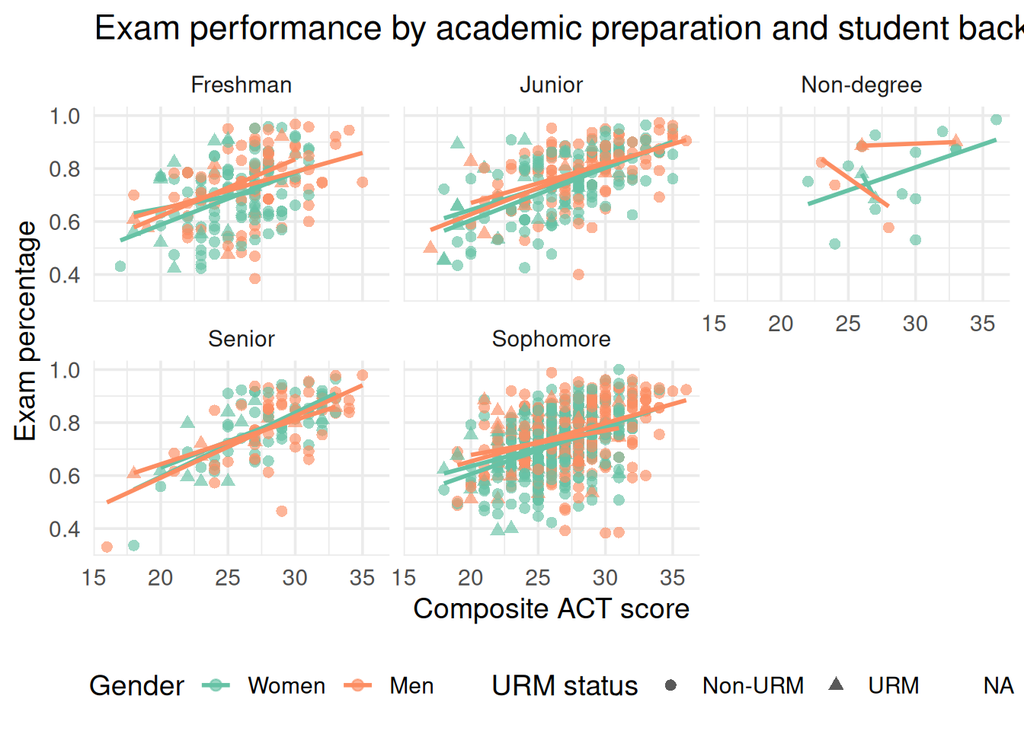

This model suggests that academic preparation is the strongest predictor of exam performance. Students with higher ACT scores tend to earn higher exam percentages, and this pattern remains visible even after accounting for gender, age, class standing, and URM status.

## Model 2: full contextual model

The second model combines the main student-background and course-context variables together.

Model 2 coefficients

| term | estimate | std.error | p.value |
| --- | --- | --- | --- |
| GenderMen | 0.020 | 0.006 | 0.001 |
| AGE | -0.003 | 0.003 | 0.281 |
| COMP_ACT_SCORE | 0.017 | 0.001 | 0.000 |
| URMURM | 0.007 | 0.010 | 0.511 |
| YearSchoolJunior | 0.029 | 0.011 | 0.010 |
| YearSchoolNon-degree | 0.032 | 0.024 | 0.174 |
| YearSchoolSenior | 0.049 | 0.015 | 0.001 |
| YearSchoolSophomore | 0.010 | 0.009 | 0.267 |
| GRADING_BASIS_ENRLS-N | -0.045 | 0.012 | 0.000 |

Model comparison

| Model | r.squared | adj.r.squared | AIC |
| --- | --- | --- | --- |
| Model 1: demographics | 0.271 | 0.266 | -1990.892 |
| Model 2: full context | 0.278 | 0.273 | -2001.909 |

This full model confirms that preparation and course context matter most once several factors are considered together. It also shows that gender remains associated with exam performance even after controlling for other variables, although the effect is modest rather than overwhelming.

Taken together, these two models suggest that exam performance is shaped by both student characteristics and course design. Preparation is the clearest predictor, while gender adds a smaller but consistent pattern on top of the other factors.

## What the models suggest

The findings point to a clear message: exam outcomes are influenced by both preparation and course structure, while gender adds an additional pattern that remains visible even after accounting for other factors.

## Easy-to-understand interpretation

In simple terms, the results suggest that academic preparation matters most. Students with higher ACT scores tend to have higher exam percentages in every model, and this relationship is very strong. That means preparation is one of the clearest predictors in the data.

The second clear pattern is that gender still matters even after accounting for preparation and other background factors. In the models, men are associated with slightly higher exam percentages than women. The effect is small but consistent across the different models, which suggests it is not just a random fluctuation.

Class standing also appears to matter somewhat. Juniors and seniors tend to have higher exam percentages than first-year students, which may reflect growing academic experience or different course positioning.

Underrepresented minority status does not show a strong independent effect once the other variables are included. In other words, the data do not show a strong separate URM effect after accounting for preparation and course context.

The grading system also matters. Courses using an S-N grading basis are associated with lower exam percentages than A-F courses, suggesting that the way a course is structured can influence how much assessment is tied to exams.

Overall, the main takeaway is that exam performance is not driven by gender alone. It appears to be shaped by a combination of academic preparation, class standing, and course design, with gender adding an additional pattern on top of those factors.